# Validación de Modelos

Una de los mayores motivos de creación de un modelo, es que el modelo funcione de manera correcta en un mundo desconocido. Al desarrollar un modelo, se trabaja en un ambiente controlado, con data controlada. Pero en producción, la data entrante es desconocida, y no importa que tan bien controlada este la data utilizada para el desarrollo del modelo, el universo de datos de producción es demasiado vasto. Para disminuir el nivel de estres de los creadores de modelos, las tecnicas de validación permiten estimar que tan bien funcionaría el modelo con datos nuevos. Hay varias formas de validar un modelo, y una buena validación es robusta y representante del objetivo del negocio que el modelo quiere resolver.

Hoy veremos varias formas de robustecer la validación de un modelo.

## Datos

Utilizaremos datos de ventas de bienes raices de Melbourne, Australia.

```python
import pandas as pd
import numpy as np
import matplotlib.pyplot as plt
data_melbourne_housing = pd.read_csv("Data_Ventas_Bienes_Raices_Melbourne.csv")
data_melbourne_housing.head()
```

|  | Num_Hab | Tipo | Precio | Distancia_Centro | Num_Banios | Num_Parqueos | Tamano_Tierra | Tamano_Edificio | Anio_Construccion |
| --- | --- | --- | --- | --- | --- | --- | --- | --- | --- |
| 0 | 4 | h | 14.285515 | 2.5 | 1.0 | 2.0 | 120.0 | 142.0 | 2014.0 |
| 1 | 3 | h | 14.444653 | 2.5 | 2.0 | 0.0 | 245.0 | 210.0 | 1910.0 |
| 2 | 2 | h | 14.307765 | 2.5 | 1.0 | 2.0 | 256.0 | 107.0 | 1890.0 |
| 3 | 3 | h | 14.115616 | 2.5 | 2.0 | 2.0 | 214.0 | 190.0 | 2005.0 |
| 4 | 2 | u | 13.527830 | 2.5 | 2.0 | 1.0 | 0.0 | 94.0 | 2009.0 |

```python
data_melbourne_housing.shape
```

```
(8561, 9)
```

### Validación Sencilla: Train y Test

La forma más sencilla de validar es separar los datos en dos sets, uno para entrenar el modelo y otro para validarlo. Esto te da una estimación para un set de datos. Como modelo utilizaremos un regresror de arbol de decision sencillo, como metrica utilizaremos el Root Mean Squared Error (RMSE).

```python
# Primero hacer un dummy con el tipo de vivienda.
data_melbourne_dummies = pd.get_dummies(data_melbourne_housing,columns=["Tipo"])
data_melbourne_dummies.head()
```

|  | Num_Hab | Precio | Distancia_Centro | Num_Banios | Num_Parqueos | Tamano_Tierra | Tamano_Edificio | Anio_Construccion | Tipo_h | Tipo_t | Tipo_u |
| --- | --- | --- | --- | --- | --- | --- | --- | --- | --- | --- | --- |
| 0 | 4 | 14.285515 | 2.5 | 1.0 | 2.0 | 120.0 | 142.0 | 2014.0 | 1 | 0 | 0 |
| 1 | 3 | 14.444653 | 2.5 | 2.0 | 0.0 | 245.0 | 210.0 | 1910.0 | 1 | 0 | 0 |
| 2 | 2 | 14.307765 | 2.5 | 1.0 | 2.0 | 256.0 | 107.0 | 1890.0 | 1 | 0 | 0 |
| 3 | 3 | 14.115616 | 2.5 | 2.0 | 2.0 | 214.0 | 190.0 | 2005.0 | 1 | 0 | 0 |
| 4 | 2 | 13.527830 | 2.5 | 2.0 | 1.0 | 0.0 | 94.0 | 2009.0 | 0 | 0 | 1 |

```python
from sklearn.model_selection import train_test_split
from sklearn.tree import DecisionTreeRegressor
X_train,X_test,y_train,y_test = train_test_split(data_melbourne_dummies.drop("Precio",axis=1),
                                                data_melbourne_dummies["Precio"],
                                                random_state=777,
                                                test_size=0.2)
X_train.head()
```

|  | Num_Hab | Distancia_Centro | Num_Banios | Num_Parqueos | Tamano_Tierra | Tamano_Edificio | Anio_Construccion | Tipo_h | Tipo_t | Tipo_u |
| --- | --- | --- | --- | --- | --- | --- | --- | --- | --- | --- |
| 6170 | 4 | 10.2 | 3.0 | 3.0 | 402.0 | 277.0 | 1950.0 | 1 | 0 | 0 |
| 6551 | 4 | 6.8 | 1.0 | 5.0 | 866.0 | 157.0 | 1920.0 | 1 | 0 | 0 |
| 4976 | 4 | 23.0 | 2.0 | 2.0 | 731.0 | 178.0 | 1985.0 | 1 | 0 | 0 |
| 7715 | 3 | 17.4 | 1.0 | 2.0 | 844.0 | 115.0 | 1975.0 | 1 | 0 | 0 |
| 7070 | 3 | 15.4 | 2.0 | 2.0 | 662.0 | 173.0 | 1980.0 | 1 | 0 | 0 |

```python
from sklearn.metrics import mean_squared_error
import numpy as np
def root_mean_squared_error(mse):
    return np.sqrt(mse)
```

```python
tree_regressor = DecisionTreeRegressor(max_depth=5)
tree_regressor.fit(X_train,y_train)
test_prediction = tree_regressor.predict(X_test)
test_score = root_mean_squared_error(mean_squared_error(test_prediction,y_test))
train_prediction = tree_regressor.predict(X_train)
train_score = root_mean_squared_error(mean_squared_error(train_prediction,y_train))
print(f"Train RMSE {train_score}, Test RMSE {test_score}")
```

```
Train RMSE 0.3109961220415291, Test RMSE 0.3197472017659485
```

Con esto, tenemos el RMSE para el set de datos aleatorio sacado de prueba. Pero esto solo nos dice el rendimiento del modelo contra **un** set de datos, lo cual no es muy robusto.

### Validación Cruzada

Para remediar esto, podemos crear varios sets de prueba, cortando los datos en pedazos y tomando un pedazo para probar y el resto para entrenar, e iterar con pedazos hasta probar con toda la data.

[figure not shown]

```python
from sklearn.model_selection import cross_validate
cv = cross_validate(DecisionTreeRegressor(max_depth=5),
                   X=data_melbourne_dummies.drop("Precio",axis=1),
                    y=data_melbourne_dummies["Precio"],
                   cv=7,
                   scoring="neg_mean_squared_error",
                   return_train_score=True)
cv["test_score"] = root_mean_squared_error(cv["test_score"] * -1)
cv["train_score"] = root_mean_squared_error(cv["train_score"] * -1)
cv
```

```
{'fit_time': array([0.01262975, 0.009974  , 0.00997233, 0.009974  , 0.01093721,
        0.00997257, 0.00997257]),
 'score_time': array([0.00199294, 0.00096297, 0.00099754, 0.00099659, 0.00099802,
        0.00099802, 0.00099802]),
 'test_score': array([0.32577613, 0.33190182, 0.33329305, 0.31924286, 0.3280755 ,
        0.34212042, 0.3173461 ]),
 'train_score': array([0.31027758, 0.30974014, 0.30912672, 0.31194099, 0.3087987 ,
        0.31118528, 0.31338598])}
```

```python
cv["test_score"].mean()
```

```
0.3282508409808245
```

Esto nos permite tener una distribucion de rendimiento del modelo, asi tambien como un solo numero para comparar con otros modelos. Sin embargo, no optimizamos los parametros del modelo, y no es recomendable utilizar la validación cruzada sola para optimización, ya que pruebas y validas con la misma data que optimizas.

### Validación en Cruz Anidada

Para resolver esto, podemos utilizar esta tecnica. Basicamente, divides los datos al igual que en la validación en cruz, llamemoslo validación exterior. Con los datos de entrenamiento resultante, realizas otra validación en cruz, con la que optimizaras los parametros del modelo, llamemoslo validación interior. Con los datos de prueba de validación exterior, pruebas los parametros optimizados encontrados.

[figure not shown]

```python
X = data_melbourne_dummies.drop("Precio",axis=1)
y = data_melbourne_dummies["Precio"]
parameters = {'max_depth':[3,5,7]}
```

```python
from sklearn.model_selection import GridSearchCV, KFold
outer_cv_scores = list()
outer_cv = KFold(3,shuffle=True)
for train,test in outer_cv.split(X):
    X_train,X_test,y_train,y_test = X.loc[train],X.loc[test],y.loc[train],y.loc[test]
    cv = GridSearchCV(DecisionTreeRegressor(), parameters, cv=5,scoring='neg_mean_squared_error',
                     return_train_score=True)
    cv.fit(X_train,y_train)
    print("Best Params")
    print(cv.best_params_)
    print("\n")
    print(f"Scoring Inner CV {root_mean_squared_error(cv.best_score_ * -1)}")
    test_prediction = cv.predict(X_test)
    test_score = root_mean_squared_error(mean_squared_error(test_prediction,y_test))
    print(f"Round Score: {test_score}")
    outer_cv_scores.append(test_score)

print(f"Outer CV Score: {np.array(outer_cv_scores).mean()}")
```

```
Best Params
{'max_depth': 7}


Scoring Inner CV 0.3153060438634847
Round Score: 0.30331609321143854
Best Params
{'max_depth': 7}


Scoring Inner CV 0.32031093716289133
Round Score: 0.30199009921166803
Best Params
{'max_depth': 7}


Scoring Inner CV 0.31398231458839826
Round Score: 0.30552624072433837
Outer CV Score: 0.3036108110491483
```

Ya con esto tenemos una validación bastante robusta. Pero aun podemos dudar de ella. Que pasa si una algunos sets de validación tienen datos infra/sobrerepresentados? Podemos utilizar otras tecnicas para mejorar nuestra estrategia de validación.

### Validación Estratificada

Los datos usualmente tienen grupos y secciones naturales o categoricos. Al dividir los datos, las divisiones pueden tener representaciones diferentes de estos grupos.

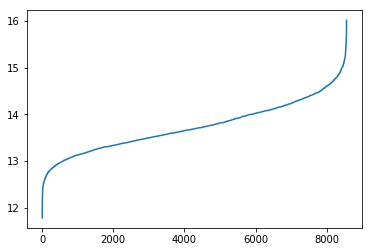

```python
y_plot = data_melbourne_housing.Precio.sort_values().values
x_plot = np.arange(0,y_plot.shape[0])
plt.plot(x_plot,y_plot)
```

Podemos tener divisiones en los datos que representen más un lado de la curva que otro. Si queremos una representación similar en los datos, podemos **estratificar** los datos antes de la división. Esto es más sencillo de implentar en clasificación, ya que el target son clases. Pero en regresión debemos crear rangos para luego estratificarlos.

```python
data_melbourne_housing.Precio.describe()
```

```
count    8561.000000
mean       13.740835
std         0.535600
min        11.782960
25%        13.355063
50%        13.687678
75%        14.096924
max        16.012735
Name: Precio, dtype: float64
```

```python
precio_ranges = pd.cut(data_melbourne_housing.Precio,bins=[11,13,14,15,17]).astype(str)
precio_ranges.value_counts()
```

```
(13, 14]    5304
(14, 15]    2536
(11, 13]     593
(15, 17]     128
Name: Precio, dtype: int64
```

```python
# Con Stratified
from sklearn.model_selection import StratifiedKFold
stratified_kfold = StratifiedKFold(3)
for train,test in stratified_kfold.split(X,precio_ranges):
    print("Test Distribution:")
    print(precio_ranges.loc[test].value_counts())
    print("\n")
```

```
Test Distribution:
(13, 14]    1768
(14, 15]     846
(11, 13]     198
(15, 17]      42
Name: Precio, dtype: int64


Test Distribution:
(13, 14]    1768
(14, 15]     845
(11, 13]     198
(15, 17]      43
Name: Precio, dtype: int64


Test Distribution:
(13, 14]    1768
(14, 15]     845
(11, 13]     197
(15, 17]      43
Name: Precio, dtype: int64
```

```python
# Sin Stratified
from sklearn.model_selection import StratifiedKFold
kfold = KFold(3)
for train,test in kfold.split(X,precio_ranges):
    print("Test Distribution:")
    print(precio_ranges.loc[test].value_counts())
    print("\n")
```

```
Test Distribution:
(13, 14]    1630
(14, 15]     910
(11, 13]     262
(15, 17]      52
Name: Precio, dtype: int64


Test Distribution:
(13, 14]    1832
(14, 15]     743
(11, 13]     248
(15, 17]      31
Name: Precio, dtype: int64


Test Distribution:
(13, 14]    1842
(14, 15]     883
(11, 13]      83
(15, 17]      45
Name: Precio, dtype: int64
```

Tambien, con esta logica podemos dividir los datos que no son el "target". Como vimos en los datos, hay varios tipos de vivienda. Estos tipos de vivienda pueden tener distribuciones de precio muy diferentes

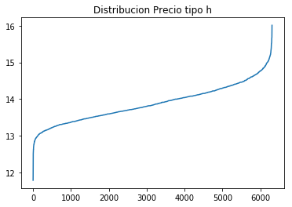

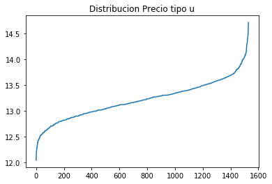

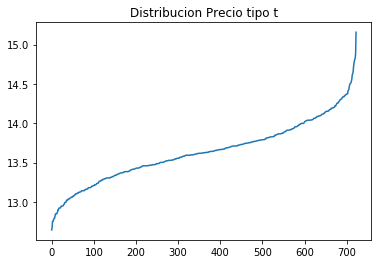

```python
for tipo in data_melbourne_housing.Tipo.unique():
    data_tipo = data_melbourne_housing.loc[data_melbourne_housing.Tipo == tipo]
    y_plot = data_tipo.Precio.sort_values().values
    x_plot = np.arange(0,y_plot.shape[0])
    plt.plot(x_plot,y_plot)
    plt.title(f"Distribucion Precio tipo {tipo}")
    plt.show()
```

Se pueden aplicar las mismas tecnicas para asegurar una propia distribución de estas categorias, con **Stratified KFold**. Alternativamente, se puede crear un modelo por cada tipo, si la varianza entre los grupos lo amerita.

## Más Recursos

- https://scikit-learn.org/stable/modules/cross_validation.html
- https://medium.com/@ODSC/the-comprehensive-guide-to-model-validation-framework-what-is-a-robust-machine-learning-model-7bdbc41c1702